# Detecting Overfitting and Overfitting Issues

Sean Schilk

4/14/26

## **Question: Reliability Application**

A mid-sized manufacturing company producing industrial conveyor systems began experiencing unexpected downtime in one of its distribution facilities, prompting concern about the reliability of a newly sourced batch of ball bearings used in the motor assemblies. These bearings, supplied by a vendor adopting cost-saving production methods, were installed across multiple units operating under continuous load conditions. After several months, maintenance logs revealed a pattern of increasing failures, with components lasting anywhere from a few dozen to over 150 hours before breakdown. To investigate, the engineering team collected time-to-failure data from 50 identical bearings and conducted a Weibull analysis within the framework of Reliability Engineering. The 50 time-to-failure (survival time) are:

```r
data <- c(12.4, 18.7, 25.3, 30.1, 33.5, 35.2, 38.9, 40.3, 42.7, 45.1, 47.6, 49.8, 52.4, 55.0, 57.3, 60.2, 62.8, 65.1, 67.9, 70.5, 72.3, 75.6, 78.2, 80.9, 83.4, 85.7, 88.1, 90.6, 93.2, 95.8, 98.4, 101.0, 104.5, 107.3, 110.6, 113.2, 116.8, 120.1, 123.7, 127.4, 130.9, 134.5, 138.2, 142.0, 146.3, 150.7, 155.2, 160.8, 168.4, 175.9)
```

a). Find the MLE of the Weibull parameters $\lambda$ (scale) and $\beta$ (shape), denoted by $\hat{\lambda}$ and $\hat{\beta}$, respectively, using the `optim()` procedure. [*Hint: You should provide explicit expressions for the log-likelihood and gradient functions of the Weibull distribution parameters.*]

```r
# log likelihood for weibull
weibull.loglik <- function(params, data){
  shape <- params[1] # k
  scale <- params[2] # lambda
  n <- length(data)

  loglik <- n * log(shape) - n * shape * log(scale) +
            (shape - 1) * sum(log(data)) -
            sum((data / scale)^shape)

  return(loglik)
}

#score equations
weibull.score <- function(params, data){
  shape <- params[1] # k
  scale <- params[2] # lambda
  n <- length(data)

    # Gradient for shape parameter
  grad_shape <- n/shape - n * log(scale) +
                sum(log(data)) -
                sum((data/scale)^shape * log(data/scale))

  # Gradient for scale parameter
  grad_scale <- -(n * shape)/scale +
                (shape/scale) * sum((data/scale)^shape)

   return(c(grad_shape, grad_scale))
}

##
# Need to provide initial values for parameters
initial.params <- c(shape = 2.2, scale = 1.5)  # Reasonable starting values


# Using optim with Nelder-Mead method
mle.result.weibull <- optim(
  par = initial.params,
  fn = weibull.loglik,
  gr = weibull.score,
  data = data,
  method = "L-BFGS-B",
  hessian = TRUE,
  control = list(trace = FALSE,
                 fnscale = -1,
                 maxit = 500,
                 abstol = 1e-8)
)
##
mle.result.weibull
```

```
$par
    shape     scale
 2.206002 99.020344

$value
[1] -256.4198

$counts
function gradient
      30       30

$convergence
[1] 0

$message
[1] "CONVERGENCE: REL_REDUCTION_OF_F <= FACTR*EPSMCH"

$hessian
            shape       scale
shape -17.5910172  0.20545413
scale   0.2054541 -0.02481606
```

b). Find the MLE of the exponential parameter $\lambda$ (scale), denoted by $\hat{\lambda}$, using any procedure. [*Hint: You should provide explicit expressions for the log-likelihood and gradient functions of the exponential distribution parameters.*]

```r
exp.loglik <- function(lambda, data){

  n <- length(data)

  negloglik <- -(n * log(lambda) - lambda * sum(data))

  return(negloglik)
}

exp.score <- function(lambda, data){

  n <- length(data)

  negscore <- -(n / lambda - sum(data))

  return(negscore)
}

# Initial value
initial.params <- c(lambda = 0.01)

# Optimization
mle.result.exp <- optim(
  par = initial.params,
  fn = exp.loglik,
  gr = exp.score,
  data = data,
  method = "L-BFGS-B",
  lower = 1e-8,
  hessian = TRUE,
  control = list(
    trace = FALSE,
    maxit = 500
  )
)

mle.result.exp
```

```
$par
    lambda
0.01141422

$value
[1] 273.6448

$counts
function gradient
       8        8

$convergence
[1] 0

$message
[1] "CONVERGENCE: REL_REDUCTION_OF_F <= FACTR*EPSMCH"

$hessian
         lambda
lambda 386744.1
```

c). Perform the likelihood ratio $\chi^2$ test on $\beta = 1$. What is the p-value? [*Hint: Use the results in a) and b)*.]

```r
#Null
initial.params <- c(shape = 2.206002 , scale = 99.020344)

l_beta_hat <- weibull.loglik(initial.params, data)
l_beta_hat
```

```
    shape
-256.4198
```

```r
# alternative
initial.params <- c(lambda <- 0.01141422 )
l_beta_not <- exp.loglik(lambda, data)

lr_stat <- 2*(l_beta_hat + l_beta_not)
lr_stat
```

```
   shape
34.44995
```

```r
pval <- 1 - pchisq(lr_stat, df = 1)
pval
```

```
       shape
4.373531e-09
```

The pvalue is near 0, leading to the reject of the null hypothesis.

d). Perform the Wald $\chi^2$ on the same hypothesis $\beta = 1$. What is the p-value? [*Hint: You need to find the observed Fisher information matrix (i.e., the negative Hessian matrix from `optim()`) based on the Weibull distribution. The inverse of the observed Hessian matrix is the covariance matrix*.]

```r
Hess <- mle.result.weibull$hessian
covar<- solve(-Hess)  # solve() finds the inverse of a square matrix

beta.hat  <- mle.result.weibull$par[1]     # based on the unrestricted likelihood estimation
se.beta <- sqrt(covar[1, 1])  # the square root of the top-left diagonal value
W <- (beta.hat - 1)^2/(se.beta)^2   # Wald test statistic
##
pval.W <- 1 - pchisq(W, df = 1)
c(W = W, pval.W = pval.W)
```

```
     W.shape pval.W.shape
2.311112e+01 1.529038e-06
```

The p-value is also near 0 implying the rejection of the null hypothesis

e). Write a summary of the above analyses to address the following:

- Whether the two tests generated the same results.
- Which model is recommended for the data.
- Draw the density curve based on the MLE(s) of the parameter(s) and describe the distribution of the time-to-failure.

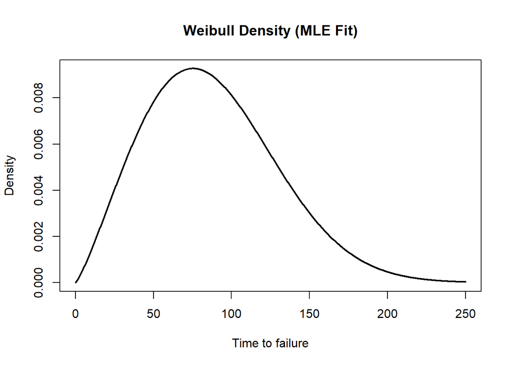

```r
beta <- mle.result.weibull$par[1]
lambda <- mle.result.weibull$par[2]

n <- seq(0, 250, length.out = 1000)

density <- dweibull(n, shape = beta, scale = lambda)

plot(n, density, type = "l", lwd = 2,
     main = "Weibull Density (MLE Fit)",
     xlab = "Time to failure",
     ylab = "Density")
```